# Predicting Exercise Activity Quality

Jim Quinn

September 26, 2015

## Background

Using devices such as Jawbone Up, Nike FuelBand, and Fitbit it is now possible to collect a large amount of data about personal activity relatively inexpensively. These type of devices are part of the quantified self movement – a group of enthusiasts who take measurements about themselves regularly to improve their health, to find patterns in their behavior, or because they are tech geeks. One thing that people regularly do is quantify how much of a particular activity they do, but they rarely quantify how well they do it. In this project, your goal will be to use data from accelerometers on the belt, forearm, arm, and dumbell of 6 participants. They were asked to perform barbell lifts correctly and incorrectly in 5 different ways. More information is available from the website here: http://groupware.les.inf.puc-rio.br/har (see the section on the Weight Lifting Exercise Dataset).

## Goal

Use data from accelerometers on the belt, forearm, arm, and dumbell of 6 participants. They were asked to perform barbell lifts correctly and incorrectly in 5 different ways. More information is available from the website here: http://groupware.les.inf.puc-rio.br/har (see the section on the Weight Lifting Exercise Dataset).

## Outcome Classification

Six young health participants were asked to perform one set of 10 repetitions of the Unilateral Dumbbell Biceps Curl in five different fashions: exactly according to the specification (Class A), throwing the elbows to the front (Class B), lifting the dumbbell only halfway (Class C), lowering the dumbbell only halfway (Class D) and throwing the hips to the front (Class E). Class A corresponds to the specified execution of the exercise, while the other 4 classes correspond to common mistakes. Participants were supervised by an experienced weight lifter to make sure the execution complied to the manner they were supposed to simulate.

## Analysis

#### The following provide code and comments describing how the analysis was performed.

### Load the Libraries

```r
library(caret)
library(rpart)
library(rpart.plot)
library(rattle)
library(randomForest)
```

### Get the Data

```r
fileURL1 <- "https://d396qusza40orc.cloudfront.net/predmachlearn/pml-training.csv"
fileURL2 <- "https://d396qusza40orc.cloudfront.net/predmachlearn/pml-testing.csv"
if (!file.exists("data")) {
  dir.create("data")
}
if (!file.exists("./data/pml-training.csv")) {
  download.file(fileURL1, destfile = "./data/pml-training.csv")
}
# Read training data with defined NA Strings
trainingData <- read.csv("./data/pml-training.csv", na.strings = c("NA","#DIV/0!",""))
if (!file.exists("./data/pml-testing.csv")) {
  download.file(fileURL2, destfile = "./data/pml-testing.csv")
}
# Read testing data with defined NA Strings
testingData <- read.csv("./data/pml-testing.csv", na.strings = c("NA","#DIV/0!",""))
```

### Clean Data

#### Choose columns to exclude from analysis

```r
# Exclude Columns with strings found in excludeColumns
excludeColumns <- grep("X|name|timestamp|window", colnames(trainingData), value = FALSE)
cleanTrainingData <- trainingData[,-excludeColumns] # 160 columns now 153
# Remove columns that contain more than 95% NAs
naRate <- apply(cleanTrainingData, 2, function(x) sum(is.na(x)))/nrow(cleanTrainingData)
cleanTrainingData <- cleanTrainingData[!(naRate > 0.95)] # 153 columns reduced to 53
cleanColumnNames <- names(cleanTrainingData)
# Add character column "classe" to tesingData, simplifying subsetting of columns in sync with cleanTrainingData.
testingData$classe <- ""
cleanTestingData <- testingData[,cleanColumnNames]
```

### Partition Training Data

#### Split provided training data into two sets - 75% myTrainingSet and 25% myTrainingTestSet

```r
set.seed(13234)
inTrain <- createDataPartition(y = cleanTrainingData$classe, p = 0.75, list = FALSE)
myTrainingSet <- cleanTrainingData[inTrain, ]
myTrainingTestSet <- cleanTrainingData[-inTrain, ]
```

### Visulize Data - Rpart Decision Tree

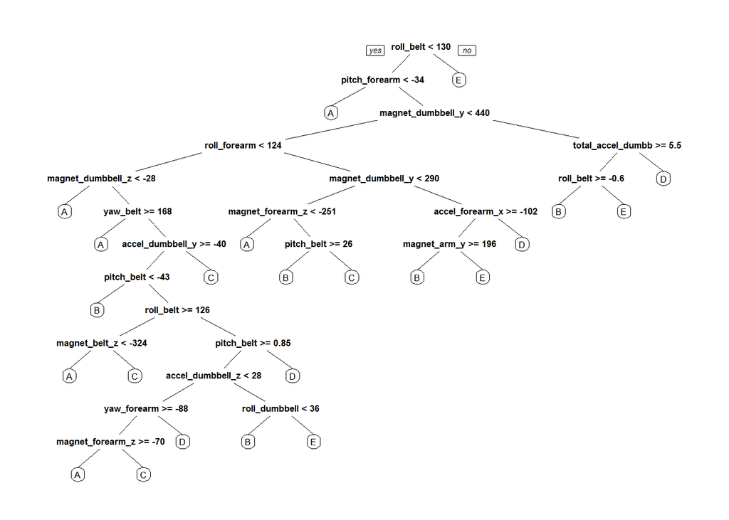

```r
model1 <- rpart(classe ~ ., data = myTrainingSet, method = "class")
prp(model1)
```

### Principal Components Analysis (PCA)

#### Using 25 for pcaComp, determine which 25 variables should be included in analysis

```r
thresh95 <- preProcess(myTrainingSet[,1:52],method = "pca",thresh = .95)
print(thresh95$numComp - 1) # 25 Components required for 95% threshold
```

```
## [1] 25
```

```r
pca <- preProcess(myTrainingSet[,1:52],method = "pca",pcaComp = 25)
pcaTraining <- predict(pca,myTrainingSet[,1:52])
```

### Create Model using Random Forests

```r
modelFit <- randomForest(myTrainingSet$classe ~ .,   data = pcaTraining, do.trace = FALSE)
print(modelFit)
```

```
##
## Call:
##  randomForest(formula = myTrainingSet$classe ~ ., data = pcaTraining,      do.trace = FALSE)
##                Type of random forest: classification
##                      Number of trees: 500
## No. of variables tried at each split: 5
##
##         OOB estimate of  error rate: 2.36%
## Confusion matrix:
##      A    B    C    D    E class.error
## A 4152   13   11    6    3 0.007885305
## B   55 2753   37    1    2 0.033356742
## C    2   37 2501   19    8 0.025710947
## D    2    2   95 2306    7 0.043946932
## E    3   16   18   11 2658 0.017738359
```

### Cross-Validation

#### In random forests, there is no need for cross-validation or a separate test set to get an unbiased estimate of the test set error. It is estimated internally, during the run.

#### OOB (out-of-bag) estimate is 2.36%

### Prediction Using Data Partitioned for Testing Split from Provided Training Data

```r
testingPredict <- predict(pca,myTrainingTestSet[,1:52])
confusionMatrix(myTrainingTestSet$classe,predict(modelFit,testingPredict))
```

```
## Confusion Matrix and Statistics
##
##           Reference
## Prediction    A    B    C    D    E
##          A 1385    3    2    4    1
##          B   14  924   10    0    1
##          C    5   13  828    8    1
##          D    5    0   29  769    1
##          E    0    3    5    8  885
##
## Overall Statistics
##
##                Accuracy : 0.977
##                  95% CI : (0.9724, 0.981)
##     No Information Rate : 0.2873
##     P-Value [Acc > NIR] : < 2.2e-16
##
##                   Kappa : 0.9708
##  Mcnemar's Test P-Value : NA
##
## Statistics by Class:
##
##                      Class: A Class: B Class: C Class: D Class: E
## Sensitivity            0.9830   0.9799   0.9474   0.9747   0.9955
## Specificity            0.9971   0.9937   0.9933   0.9915   0.9960
## Pos Pred Value         0.9928   0.9737   0.9684   0.9565   0.9822
## Neg Pred Value         0.9932   0.9952   0.9886   0.9951   0.9990
## Prevalence             0.2873   0.1923   0.1782   0.1609   0.1813
## Detection Rate         0.2824   0.1884   0.1688   0.1568   0.1805
## Detection Prevalence   0.2845   0.1935   0.1743   0.1639   0.1837
## Balanced Accuracy      0.9901   0.9868   0.9703   0.9831   0.9958
```

#### Accuracy is 97.7% - which means out of sample error is 2.3%.

## Applying machine learning algorithm to the 20 test cases

```r
testDataPrediction <- predict(pca,cleanTestingData[,1:52])
cleanTestingData$classe <- predict(modelFit,testDataPrediction)
answers <- predict(modelFit,testDataPrediction)
```

### Submitted all test case predictions, recieving confirmation of 100% accuracy!

## References/Citations

Data set for this analysis provided by:

Velloso, E.; Bulling, A.; Gellersen, H.; Ugulino, W.; Fuks, H. Qualitative Activity Recognition of Weight Lifting Exercises. Proceedings of 4th International Conference in Cooperation with SIGCHI (Augmented Human ’13) . Stuttgart, Germany: ACM SIGCHI, 2013.